# Regionalisation of the world by media flows

Sirius Project - Working Paper 003

Author

Claude Grasland

Published

2026-02-24

## Research question

- RQ1 : Which countries are the most mentionned in the news ? What are the variations according to media or time period ?How to aggregate the data from different sources.
- RQ2 : What is the similarity between media playing the role of guest ? Is it based on distance or regiobal clusters.
- RQ3 : What is the similarity between host countries described by various media ? Is it based on distance or regiobal clusters.
- RQ4 : Can we find a correspondance between the location of guest countries and media ?

## (A) Data preparation

### Load media

We load the hypercube of each of the media of the database. Then we keep only the countries or territories that fit with the map.

### Matrix crossing host media and guest countries

Finally we standardize in order to obtain a salience of frequency per 100,000 news.

### Discussion

Matrix of interaction between host media and guest countries (p.100,000)

|  | ARG_nacion | AUS_sydmor | BRA_oglobo | CAN_tostar | CHN_mopost |
| --- | --- | --- | --- | --- | --- |
| AFG_Afghanistan | 157 | 597 | 474 | 808 | 362 |
| AGO_Angola | 38 | 15 | 130 | 15 | 23 |
| ALB_Albania | 27 | 8 | 14 | 41 | 10 |
| AND_Andorra | 34 | 0 | 6 | 3 | 3 |
| ARE_United Arab Emirates | 91 | 176 | 66 | 144 | 107 |
| ARG_Argentina | NA | 488 | 3927 | 295 | 319 |
| ARM_Armenia | 44 | 14 | 35 | 18 | 12 |
| AUS_Australia | 1492 | NA | 1219 | 1060 | 2913 |
| AUT_Austria | 220 | 143 | 241 | 208 | 77 |
| AZE_Azerbaijan | 30 | 23 | 53 | 13 | 24 |

- **Comment** :
  - Lecture in column : over the period of observation, the proportion of foreign news published by La Nacion about Australia is equal to 1492/100,000 or 1.49 % . It is much more than the news about Afghanistan which is 157/10000 or 0.16% The number of news published by this media about Argentina is not available as the location of the host media is Argentina and the news is not a foreign one.
  - lecture in line : Argentina is more likely to be present in the news published by the Brazilian media O Globo frm Brazil (3.93%) than in the news published by the Toronto Star from Canada (0.29%)

## (B) TOP COUNTRIES

We propose here to identify the top countries in the sample of media that we have selected.

### Compute parameters

| Rank | Code | Name | Salience (Q2) | Variability (IQR/Q2) | Mean | st. dev. | min | Q1 | Q3 | max |
| --- | --- | --- | --- | --- | --- | --- | --- | --- | --- | --- |
| 1 | USA | United States of America | 15048 | 0.51 | 16638 | 5219 | 6916 | 13156 | 20865 | 28147 |
| 2 | CHN | China | 4999 | 0.90 | 6243 | 3723 | 1917 | 3503 | 8011 | 16014 |
| 3 | GBR | United Kingdom | 4799 | 0.83 | 4524 | 2072 | 1399 | 2441 | 6433 | 7625 |
| 4 | RUS | Russia | 2839 | 0.54 | 4397 | 6804 | 1528 | 2327 | 3847 | 37290 |
| 5 | FRA | France | 2471 | 0.68 | 2849 | 1521 | 890 | 1750 | 3442 | 6858 |
| 6 | SYR | Syria | 2288 | 0.75 | 2703 | 1643 | 751 | 1572 | 3290 | 7473 |
| 7 | DEU | Germany | 1883 | 0.93 | 2243 | 1278 | 892 | 1274 | 3024 | 5199 |
| 8 | JPN | Japan | 1880 | 0.53 | 2228 | 1349 | 659 | 1670 | 2668 | 7738 |
| 9 | IRN | Iran | 1688 | 0.58 | 1963 | 1976 | 320 | 1134 | 2114 | 11088 |
| 10 | TUR | Turkey | 1590 | 0.87 | 1814 | 1098 | 536 | 935 | 2326 | 4261 |
| 11 | IND | India | 1484 | 0.70 | 1920 | 1663 | 634 | 1076 | 2114 | 9428 |
| 12 | ESP | Spain | 1368 | 0.89 | 1719 | 985 | 537 | 998 | 2209 | 4597 |
| 13 | AUS | Australia | 1206 | 0.88 | 1598 | 1232 | 186 | 743 | 1800 | 5058 |
| 14 | ISR | Israel | 1179 | 0.65 | 1470 | 744 | 565 | 963 | 1733 | 3269 |
| 15 | ITA | Italy | 1164 | 0.94 | 1559 | 799 | 393 | 1041 | 2138 | 3330 |
| 16 | BRA | Brazil | 1079 | 0.68 | 1498 | 1255 | 121 | 957 | 1691 | 6728 |
| 17 | EGY | Egypt | 1048 | 0.60 | 1218 | 643 | 503 | 864 | 1488 | 3146 |
| 18 | IRQ | Iraq | 1007 | 0.75 | 1443 | 1345 | 222 | 658 | 1418 | 5372 |
| 19 | UKR | Ukraine | 999 | 0.70 | 1773 | 3473 | 463 | 697 | 1395 | 18594 |
| 20 | PRK | North Korea | 827 | 0.79 | 1204 | 1533 | 94 | 514 | 1168 | 8364 |
| 21 | CAN | Canada | 731 | 0.57 | 780 | 299 | 387 | 541 | 954 | 1602 |
| 22 | SAU | Saudi Arabia | 713 | 0.84 | 1016 | 999 | 0 | 452 | 1051 | 3903 |
| 23 | KOR | South Korea | 704 | 0.63 | 1134 | 1707 | 201 | 499 | 946 | 9157 |
| 24 | NLD | Netherlands | 680 | 0.39 | 705 | 268 | 224 | 548 | 811 | 1394 |
| 25 | PAK | Pakistan | 676 | 0.78 | 1038 | 1829 | 135 | 476 | 1006 | 9859 |

### Size and variability

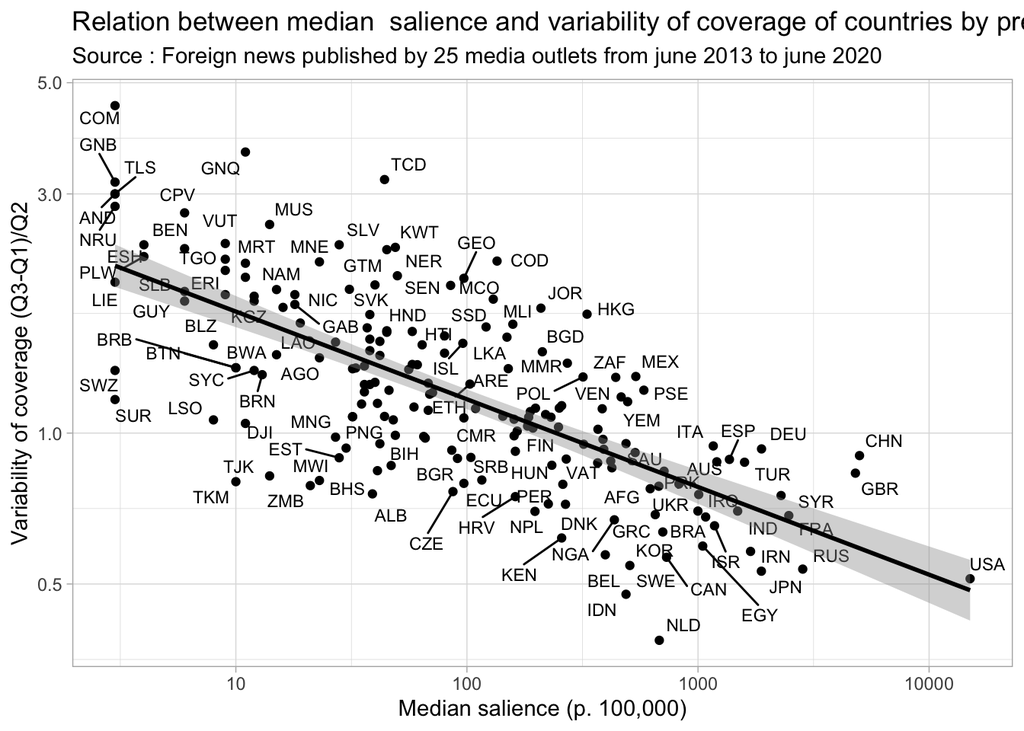

```
    Pearson's product-moment correlation

data:  log(tab$Q2) and log(tab$IQR)
t = -13.453, df = 185, p-value < 2.2e-16
alternative hypothesis: true correlation is not equal to 0
95 percent confidence interval:
 -0.7690999 -0.6225387
sample estimates:
       cor
-0.7032138
```

```
    Spearman's rank correlation rho

data:  log(tab$Q2) and log(tab$IQR)
S = 1835810, p-value < 2.2e-16
alternative hypothesis: true rho is not equal to 0
sample estimates:
       rho
-0.6844832
```

### Map of average salience

We use a polar projection

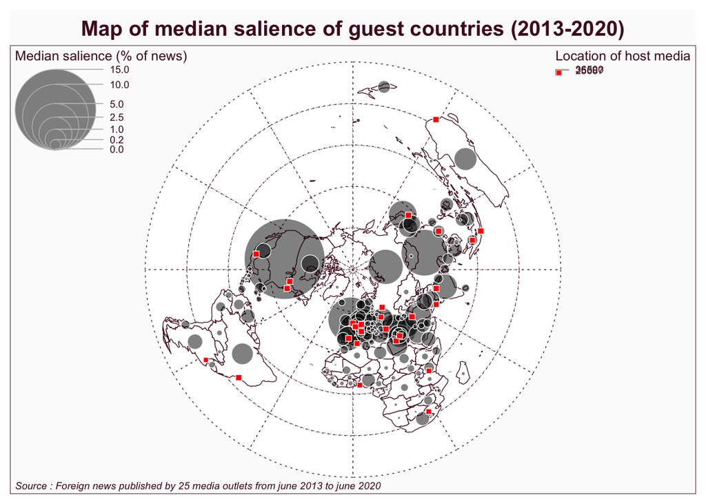

### Dorling cartogram

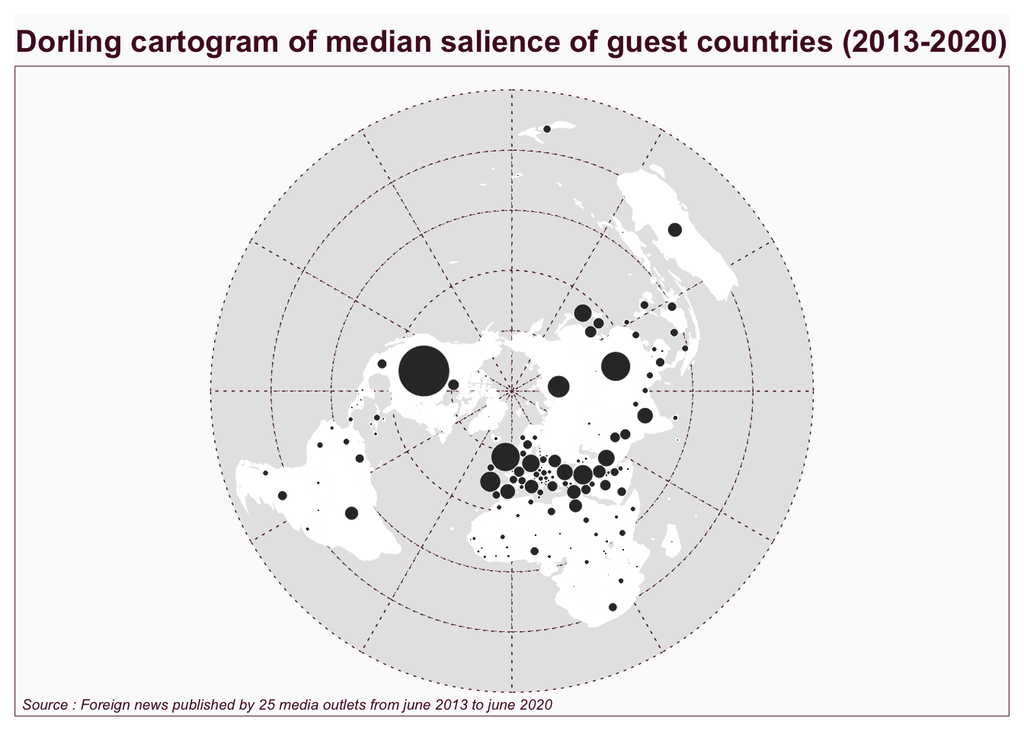

## (C) CORRELATION ANALYSIS 1 : HOST MEDIA

### Correlation matrix

We establish a correlation matrix based on the Spearman correlation coefficient based on rank. The rank correlation has been chosen against the classical Pearson coefficient because it is less influenced by the weight of top countries (USA, China, Russia, …) and is more likely to reval regional organisation of news at world scale.

The correlation are based after exclusion of the host countries (where media are located) . For example, the correlation between *Le Monde* and *Times of India* will exclude the salience of France and India from the vectors of values used for the measure of correlation.

Spearman correlation coefficient between median values

|  | ARG_nacion | AUS_sydmor | BRA_oglobo | CAN_tostar | CHN_mopost |
| --- | --- | --- | --- | --- | --- |
| ARG_nacion | 1.000 | 0.648 | 0.872 | 0.747 | 0.625 |
| AUS_sydmor | 0.648 | 1.000 | 0.726 | 0.841 | 0.870 |
| BRA_oglobo | 0.872 | 0.726 | 1.000 | 0.818 | 0.722 |
| CAN_tostar | 0.747 | 0.841 | 0.818 | 1.000 | 0.809 |
| CHN_mopost | 0.625 | 0.870 | 0.722 | 0.809 | 1.000 |

- **Comment** : The media *La Nacion* from Argentina is much more correlated with the brasilian newspaper *O Globo* ($\rho = + 0.87$) than with the *Sydney Morning Herald* ($\rho = + 0.65$) or the *South China Morning Post* ($\rho = + 0.62$). Reversely the *Sydney Morning Herald* is much more correlated with the *South China Morning Post* ($\rho = + 0.87$) than with *O Globo* ($\rho = + 0.73$). This example suggest the existence of a latent structure likely to reveal clusters of country characterized by higher levels of correlation.

### Principal Component Analysis

The PCA provide a first viusalization of the proximity between media and some clustrs can be easily observed on the plan defined by the two first component. It is a simple approximation and better results could be obtained with Multi Dimensional Scaling (MDS) or Network Analysis (it will be done later).

[interactive chart not shown]

- **Comment** : The figure reveals immediately a clustering of media based on geographical or language proximity. Notice the specific situation of the french media *Le Monde* in an intermediate position between media from Western Europe and media from Northern Africa.

### Hierarchical Cluster Analysis

The hierarchical cluster analysis is realized on the components of the previous PCA.

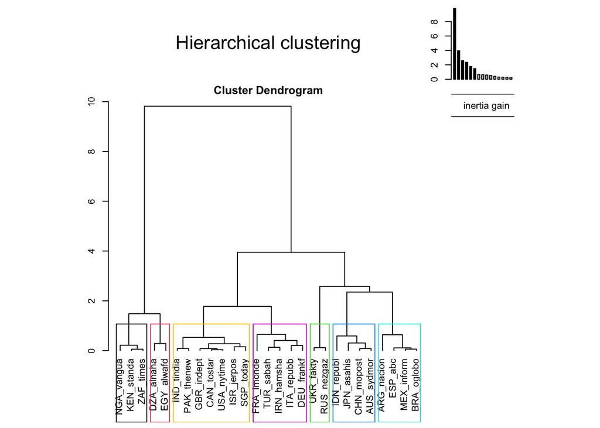

- **Comment :** The analysis of the inertia of the tree suggest a partition in 3 groups and 7 subgroups. Group A is the most original and reveals the specificity of host media located in northern Africa (A.1) and subsaharan Africa (A.2). This strong break in the tree suggest the existence of a mediatic region of Africa, related to a specific arena of news covering this continent. The group B is mainly associated to rich countries of the Global North but with interesting exceptions. The subgroup B.1 is only associated to media of english speaking countries historically associated to UK or the US (Canada, India, Pakistan, Singapore, Canada, Israel). The subgroup B.2 associates media located in three major european countries (Italy, France, Germany) with two media located in Turkey and Iran. The group C is globally more heterogenous but the different subgroups located inside are more coherent. the subgroup C.1 associates Russia and Ukraine. The subgroup C.2 associates media located countries from the Asia-Pacifica region. The subgroup C.3 associates three media located in Latin America and a media from Spain which suggest an effect of language or colonial inheritage.

But the clustering approach introduce barriers in a reality which is in practice more complex. And we prefer to complete the analysis by a network approach where we have represented for each media outlet the links with three media having the highest level of correlation.

### Network analysis

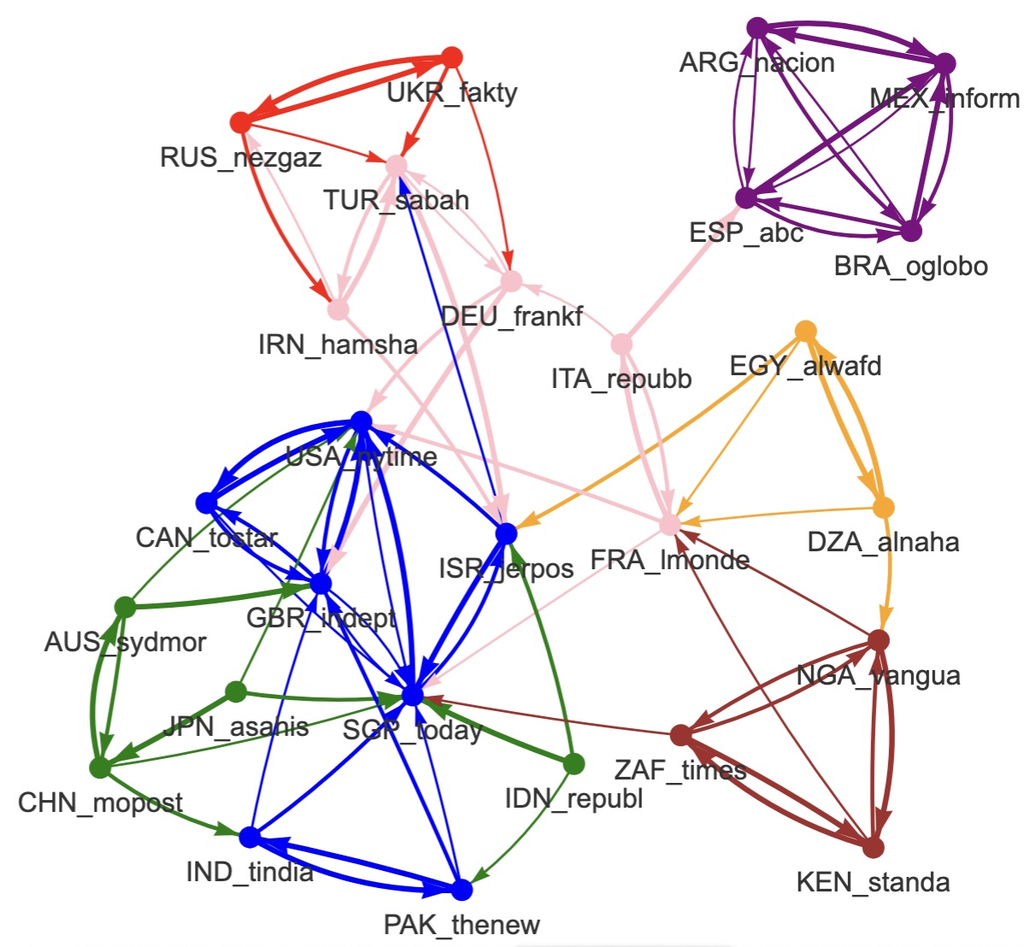

Network of top correlations between media coverage

## (D) CORRELATION ANALYSIS 2 : GUEST COUNTRIES

```
           AFG_Afghanistan AGO_Angola ALB_Albania
ARG_nacion             157         38          27
AUS_sydmor             597         15           8
BRA_oglobo             474        130          14
```

|  | NOR | DNK | FIN | COL | PER | CHL | LBN | JOR | SAU |
| --- | --- | --- | --- | --- | --- | --- | --- | --- | --- |
| NOR | 1.00 | 0.47 | 0.76 | 0.04 | -0.05 | -0.04 | -0.18 | -0.18 | -0.24 |
| DNK | 0.47 | 1.00 | 0.21 | -0.05 | -0.13 | -0.11 | -0.14 | 0.22 | -0.05 |
| FIN | 0.76 | 0.21 | 1.00 | 0.03 | -0.11 | -0.06 | -0.26 | -0.19 | -0.35 |
| COL | 0.04 | -0.05 | 0.03 | 1.00 | 0.93 | 0.86 | -0.23 | -0.27 | -0.26 |
| PER | -0.05 | -0.13 | -0.11 | 0.93 | 1.00 | 0.87 | -0.07 | -0.11 | -0.01 |
| CHL | -0.04 | -0.11 | -0.06 | 0.86 | 0.87 | 1.00 | -0.23 | -0.24 | -0.24 |
| LBN | -0.18 | -0.14 | -0.26 | -0.23 | -0.07 | -0.23 | 1.00 | 0.62 | 0.37 |
| JOR | -0.18 | 0.22 | -0.19 | -0.27 | -0.11 | -0.24 | 0.62 | 1.00 | 0.37 |
| SAU | -0.24 | -0.05 | -0.35 | -0.26 | -0.01 | -0.24 | 0.37 | 0.37 | 1.00 |

### Hierarchical Cluster Analysis

The hierarchical cluster analysis is realized on the matrix of dissimilarity between $D$ defined as the difference between 1 and the Spearman correlation coefficient :

$D_{ij} = 1 - \rho_{ij}$

We can then apply different clustering methods. We have chosen here the classical method of Ward.

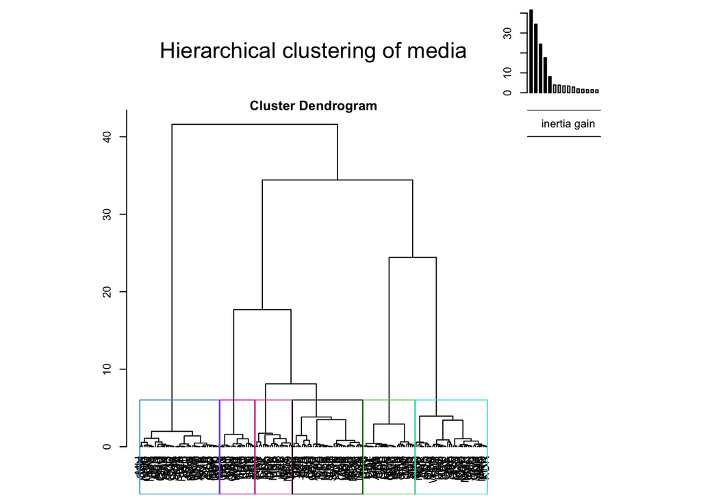

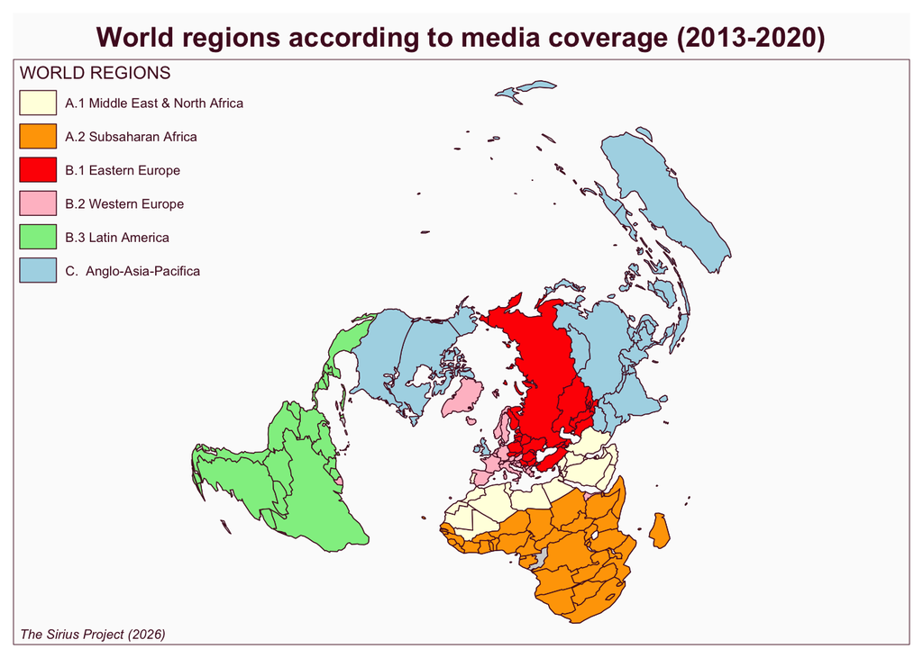